# kreyszig-10-1

## Erwin Kresyzig 10.1 Problems

### 2-11 LINE INTEGRAL. WORK.

Calculate $$\int_{C} \mathbf{F}(\mathbf{r}) \cdot d\mathbf{r}$$ for the given data. If $\mathbf{F}$ is a force, this gives the work done by the force in the displacement along $C$. Show the details.

We repeat for clarity the definition of the “line” integral $\mathbf{F} \cdot d\mathbf{r}$ along the curve $C$ from first principles.

The integral along $C$ is defined as:

$$\int_C \mathbf{F} \cdot d\mathbf{r}$$

where $\mathbf F$ and $\mathbf r$ are vector functions to be expanded in vector components as:

$\mathbf F = [F_1, F_2, F_3] = F_1 \mathbf i + F_2 \mathbf j + F_3 \mathbf k,$

$\mathbf r(t) = [x(t), y(t), z(t)] = x(t)\mathbf{i} + y(t)\mathbf{j} + z(t)\mathbf{k},$

and the differential $ d \mathbf r = \left[ dx, dy , dz\right] .$

$\mathbf F = [F_1, F_2, F_3]$ is a vector function in the $3$-dimensional space to be evaluated along the path $C$ defined by $\mathbf r(t),$ i. e., $\mathbf F$ is $ \left([F_1, F_2, F_3]\right) \left(\mathbf r(t)\right).$

The differential $d\mathbf r$ may be calculated by chain rule:

$$ d\mathbf r = \frac{d\mathbf r(t)}{dt} dt = \mathbf r^\prime (t) dt. $$

The components are,

$$\frac{d}{dt} \mathbf r(t) = \frac{d}{dt} \left[x(t), y(t), z(t)\right] = \left[ \frac{d}{dt} x(t), \frac{d}{dt} y(t), \frac{d}{dt} z(t) \right] = \left[ x^\prime (t), y^\prime (t) , z^\prime (t) \right] $$

or more concisely:

$$ \mathbf dr = \left[dx, dy, dz \right] = \left[ x^\prime (t), y^\prime (t) , z^\prime (t) \right] dt . $$

Thus the dot product in the integrand is, along $C,$

$$ \begin{align*} \mathbf{F} \cdot d\mathbf{r} &= [F_1, F_2, F_3] \cdot [dx, dy, dz] \\ &= \left([F_1, F_2, F_3]\right) \left(\mathbf r(t)\right) \cdot \left[ x^\prime (t), y^\prime (t) , z^\prime (t) \right] dt \\ &= \left( (F_1 (\mathbf r(t)) \cdot x^\prime (t) + (F_2(\mathbf r(t))) \cdot y^\prime (t) + (F_3(\mathbf r(t))) \cdot z^\prime (t) \right) dt \end{align*} $$

Thus the line integral in in the $3$-dimensional space is reduced to an integral in one variable along a closed interval in the real line, say, $[a, b].$

#### 2.

$F = [y^2, -x^2]$, $C: y = 4x^2$ from $(0, 0)$ to $(1, 4)$

Given $\mathbf{F} = [y^2, -x^2]$ and $C: y = 4x^2$ from $(0,0)$ to $(1,4)$, we have to compute the line integral:

$$ \int_C \mathbf{F} \cdot d\mathbf{r} = \int_C (y^2 \, dx - x^2 \, dy). $$

Here $ \mathbf{F} = y^2 \mathbf{i} - x^2 \mathbf{j}.$

So $F_1=y^2$ and $F_2 = -x^2.$

Parameterize $C$ using $x = t$, so $y = 4t^2$, and $t$ goes from 0 to 1.

For differentials, $dx = dt$ and $dy = 8t dt.$

Substituting into the integrand: $ \mathbf{F} = y^2 \mathbf{i} - x^2 \mathbf{j}$ and expanding dot product:

$$ \begin{align*} \mathbf{F} \cdot d\mathbf{r} &= F_1 dx + F_2 dy = y^2 dx - x^2 dy \\ &= (4t^2)^2 \, dt - t^2 (8t \, dt) \\ &= 16t^4 \, dt - 8t^3 \, dt \\ &= (16t^4 - 8t^3) \, dt \end{align*} $$

Integrating:

$$ \begin{aligned} \int_0^1 (16t^4 - 8t^3) \, dt &= \left[ \frac{16t^5}{5} - \frac{8t^4}{4} \right]_0^1 \\ &= \frac{16}{5} - \frac{8}{4} \\ &= \frac{16}{5} - 2 = \frac{6}{5}. \end{aligned} $$

#### 3

$F$ as in Prob. 2, $C$ from $(0, 0)$ straight to $(1, 4)$. Compare.

Using same $\mathbf{F} = [y^2, -x^2]$ from previous problem. Now $C$ is the straight line from $(0,0)$ to $(1,4)$, i.e., $y = 4x$.

Parameterize: $x = t$, $y = 4t$, $t$ from 0 to 1.

Differentials: $dx = dt$, $dy = 4 \, dt.$

Substituting into integrand:

$$ \begin{align*} \mathbf{F} \cdot d\mathbf{r} &= (4t)^2 \, dt - t^2 (4 \, dt) \\ &= 16t^2 \, dt - 4t^2 \, dt \\ &= 12t^2 \, dt \end{align*} $$

Integrating:

$$ \int_0^1 12t^2 \, dt = \left[ 12 \frac{t^3}{3} \right]_0^1 = 12 \cdot \frac{1}{3} = 4. $$

**Comparison:** The work done differs from problem $2$ for same function along the parabolic path, where it was $\frac{6}{5} = 1.2$. Here, it is 4. Thus integral of $\mathbf{F}$ is not path-independent.

#### 4.

$F = [xy, x^2 y^2]$, $C$ from $(2, 0)$ straight to $(0, 2)$

$C$ is the straight line from $(2,0)$ to $(0,2)$, i.e., $y = -x + 2$.

Parameterize: $x = 2-t$, $y = t$, $t$ from 0 to 2.

Differentials: $dx = -dt$, $dy = dt$.

Substitute:

$$ \begin{align*} \mathbf{F} \cdot d\mathbf{r} &= (2-t)t (-dt) + (2-t)^2 t^2 (dt) \\ &= (t^4 - 4t^3 + 5t^2 - 2t) \, dt \end{align*} $$

Integrate: $$ \begin{aligned} \int_0^2 (t^4 - 4t^3 + 5t^2 - 2t) \, dt &= \left[ \frac{t^5}{5} - \frac{4t^4}{4} + \frac{5t^3}{3} - \frac{2t^2}{2} \right]_0^2 \\ &= \frac{32}{5} - 16 + \frac{40}{3} - 4 \\ &= -\frac{4}{15}. \end{aligned} $$

#### 5

$F$ as in Prob. 4, $C$ the quarter-circle from $(2, 0)$ to $(0, 2)$ with center $(0, 0)$

Using $\mathbf{F} = [xy, x^2 y^2]$, $C$ is the quarter-circle from $(2,0)$ to $(0,2)$, center $(0,0)$, radius 2.

Parameterize: $\mathbf{r} = [2 \cos t, 2 \sin t]$, $t$ from 0 to $\frac{\pi}{2}$.

Differentials: $dx = -2 \sin t \, dt$, $dy = 2 \cos t \, dt$.

Thus

$$\mathbf{F} = [4 \cos t \sin t, 16 \cos^2 t \sin^2 t].$$

$$\mathbf{F} \cdot d\mathbf{r} = 8 \cos t \sin^2 t (-1 + 4 \cos^2 t) \, dt$$

Substitute $u = \sin t$, $du = \cos t \, dt.$ Thus $du= \cos t dt$ and $u^2 = \sin^2 t$ and $\cos^2 t = 1 -u^2.$

For the substitution, when $t=0, \pi/2$ resp., corresponding $u = 0, 1$ resp. as $t = 0 \implies u = \sin 0 =0$ and $t = \pi /2 \implies u = \sin \pi /2 =1.$

Integrating with $u$ from 0 to 1:

$$ \begin{aligned} \int_0^1 8 (3u^2 - 4u^4) \, du &= 8\left[ 3\frac{u^3}{3} - 4\frac{u^5}{5} \right]_0^1 \\ &= 8 \left( 1 - \frac{4}{5} \right) \\ &= \frac{8}{5}. \end{aligned} $$

#### 6

$F = [x - y, y - z, z - x]$, $C: \mathbf{r} = [2 \cos t, t, 2 \sin t]$ from $(2, 0, 0)$ to $(2, 2\pi, 0)$

$C: \mathbf{r} = [2 \cos t, t, 2 \sin t]$, $t$ from 0 to $2\pi.$

Differentials: $dx = -2 \sin t \, dt$, $dy = \, dt,$ $dz = 2 \cos t \, dt.$

Thus

$$\mathbf{F} = [2 \cos t - t, t - 2 \sin t, 2 \sin t - 2 \cos t]$$

and

$$ \begin{align*} \mathbf{F} \cdot d\mathbf{r} &= \left((2 \cos t - t)(-2 \sin t) + (t - 2 \sin t) + (2 \sin t - 2 \cos t)(2 \cos t)\right) \, dt \\ &= \left( t (2 \sin t + 1) - 2 \sin t - 4 \cos^2 t \right) \, dt. \end{align*} $$

Thus to compute the line integral:

#### 7

$F = [x^2, y^2, z^2]$, $C: \mathbf{r} = [\cos t, \sin t, e^t]$ from $(1, 0, 1)$ to $(1, 0, e^{2\pi})$. Sketch $C$.

Given $\mathbf{F} = [x^2, y^2, z^2]$, $C: \mathbf{r} = [\cos t, \sin t, e^t]$, $t$ from 0 to $2\pi$.

Differentials: $dx = -\sin t \, dt$, $dy = \cos t \, dt$, $dz = e^t \, dt$.

$\mathbf{F} = [\cos^2 t, \sin^2 t, e^{2t}]$.

$\mathbf{F} \cdot d\mathbf{r} = \sin t \cos t (\sin t - \cos t) \, dt + e^{3t} \, dt$.

To integrate the first term: The integrand and integral are periodic functions of period $2\pi,$ thus, evaluating, the definite integral between $0$ and $2\pi$ is $0.$

Another way to see is to integrate $\sin^2 t \cos t$ and $\sin t \cos^2 t$ separately via appropriate substitutions, and observe that the upper and lower limits are same ($=0$.)

To integrate second term:

$$ \int_0^{2\pi} e^{3t} \, dt = \left[ \frac{e^{3t}}{{3}} \right]_0^1 = \frac{e^{6\pi} - 1}{3}. $$

**Sketch:** The curve is a spiral on the cylinder $x^2 + y^2 = 1$, with $z$ increasing from 1 to $e^{2\pi}$ at the speed of exponential function.

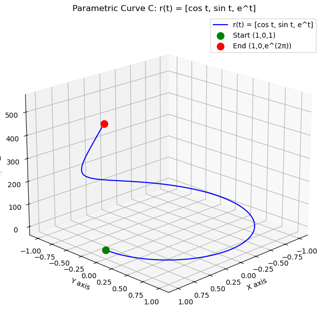

```python
import numpy as np
import matplotlib.pyplot as plt
from mpl_toolkits.mplot3d import Axes3D

# Create parameter t from 0 to 2π
t = np.linspace(0, 2*np.pi, 100)

# Calculate x, y, z coordinates
x = np.cos(t)
y = np.sin(t)
z = np.exp(t)

# Create 3D plot
fig = plt.figure(figsize=(10, 8))
ax = fig.add_subplot(111, projection='3d')

# Plot the curve
ax.plot(x, y, z, 'b-', label='r(t) = [cos t, sin t, e^t]')

# Plot start and end points
ax.scatter([1], [0], [1], color='green', s=100, label='Start (1,0,1)')
ax.scatter([1], [0], [np.exp(2*np.pi)], color='red', s=100, label='End (1,0,e^(2π))')

# Set labels
ax.set_xlabel('X axis')
ax.set_ylabel('Y axis')
ax.set_zlabel('Z axis')
ax.set_title('Parametric Curve C: r(t) = [cos t, sin t, e^t]')

# Add legend
ax.legend()

# Adjust the view angle
ax.view_init(elev=20, azim=45)

plt.show()
```

#### 8

Let $F = [e^x, \cosh y, \sinh z]$, $C: \mathbf{r} = [t, t^2, t^3]$ from $(0, 0, 0)$ to $\left(\frac{1}{2}, \frac{1}{4}, \frac{1}{8}\right)$. Sketch $C$.

Let $\mathbf{F} = [e^x, \cosh y, \sinh z]$, $C: \mathbf{r}(t) = [t, t^2, t^3]$ from $(0, 0, 0)$ to $\left(\frac{1}{2}, \frac{1}{4}, \frac{1}{8}\right)$, so $t$ ranges from 0 to $\frac{1}{2}$.

Differentials: $dx = dt$, $dy = 2t \, dt$, $dz = 3t^2 \, dt$.

Then, $d\mathbf{r} = [1, 2t, 3t^2] \, dt$, and along $C$, $\mathbf{F} = [e^t, \cosh (t^2), \sinh (t^3)]$, so:

$$ \begin{aligned} \int_C \mathbf{F} \cdot d\mathbf{r} &= \int_0^{\frac{1}{2}} [e^t + 2t \cosh (t^2) + 3t^2 \sinh (t^3)] \, dt \\ &= \int_0^{\frac{1}{2}} e^t \, dt + \int_0^{\frac{1}{4}} \cosh u \, du + \int_0^{\frac{1}{8}} \sinh v \, dv \\ &= [e^t]_0^{\frac{1}{2}} + [\sinh u]_0^{\frac{1}{4}} + [\cosh v]_0^{\frac{1}{8}} \\ &= (e^{\frac{1}{2}} - 1) + \sinh \frac{1}{4} + (\cosh \frac{1}{8} - 1) \\ &= e^{\frac{1}{2}} + \sinh \frac{1}{4} + \cosh \frac{1}{8} - 2. \end{aligned} $$ (Substitutions: $u = t^2$, $v = t^3$.)

**Sketch:** The curve follows $y = x^2$, $z = x^3$, a winding 3D curve from $(0,0,0)$ to $\left(\frac{1}{2}, \frac{1}{4}, \frac{1}{8}\right)$. The projections to $xy$ and $xz$ axes give $y = x^2$ and $z = x^3$.

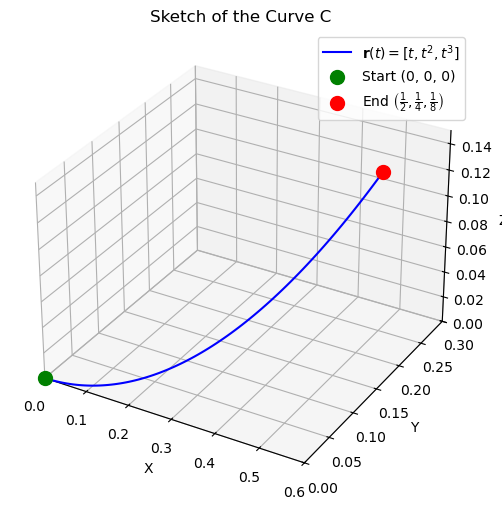

```python
# Import required libraries
import numpy as np
import matplotlib.pyplot as plt
from mpl_toolkits.mplot3d import Axes3D

# Define the parameter t
t = np.linspace(0, 0.5, 100)  # 100 points from t=0 to t=0.5

# Parametric equations
x = t
y = t**2
z = t**3

# Create a 3D plot
fig = plt.figure(figsize=(8, 6))
ax = fig.add_subplot(111, projection='3d')

# Plot the curve
ax.plot(x, y, z, label=r'$\mathbf{r}(t) = [t, t^2, t^3]$', color='blue')

# Mark the start and end points
ax.scatter([0], [0], [0], color='green', s=100, label='Start (0, 0, 0)')
ax.scatter([0.5], [0.25], [0.125], color='red', s=100, label=r'End $\left(\frac{1}{2}, \frac{1}{4}, \frac{1}{8}\right)$')

# Set labels and title
ax.set_xlabel('X')
ax.set_ylabel('Y')
ax.set_zlabel('Z')
ax.set_title('Sketch of the Curve C')
ax.legend()

# Set axis limits for better visualization
ax.set_xlim(0, 0.6)
ax.set_ylim(0, 0.3)
ax.set_zlim(0, 0.15)

# Show the plot
plt.show()
```

#### 9

Let $F = [x + y, y + z, z + x]$, $C: \mathbf{r} = [2t, 5t, t]$ from $t = 0$ to $1$. Also from $t = -1$ to $1$.

Given $\mathbf{F} = [x+y, y+z, z+x]$, $C: \mathbf{r} = [2t, 5t, t]$.

Differentials: $dx = 2 \, dt$, $dy = 5 \, dt$, $dz = dt$.

$\mathbf{F} = [7t, 6t, 3t].$

$d \mathbf{r} = [2 , 5, 1]dt.$

$\mathbf{F} \cdot d\mathbf{r} = 47t \, dt$.

Integrate from $t=0$ to 1: $$\int_0^1 47t \, dt = \frac{47}{2}.$$

From $t=-1$ to 1: $$\int_{-1}^1 47t \, dt = 0.$$

#### 10

Let $F = [x, -z, 2y]$ from $(0, 0, 0)$ straight to $(1, 1, 0)$, then to $(1, 1, 1)$, back to $(0, 0, 0)$.

$C$ is a closed triangular loop: $(0,0,0)$ to $(1,1,0)$, to $(1,1,1)$, to $(0,0,0)$.

Side 1:

$\mathbf{r}(t) = [t, t, 0]$, $t$ from 0 to 1, $d\mathbf{r} = [1, 1, 0] \, dt$, $\mathbf{F} = [t, 0, 2t]$, so $\mathbf{F} \cdot d\mathbf{r} = t \, dt$. Then,

$$\int_0^1 t \, dt = \frac{1}{2}.$$

Side 2:

$\mathbf{r}(t) = [1, 1, t]$, $t$ from 0 to 1, $d\mathbf{r} = [0, 0, 1] \, dt$, $\mathbf{F} = [1, -t, 2]$, so $\mathbf{F} \cdot d\mathbf{r} = 2\, dt$. Then, $$\int_0^1 2 \, dt = 2.$$

Side 3:

$\mathbf{r}(t) = [1-t, 1-t, 1-t]$, $t$ from 0 to 1, $d\mathbf{r} = [-1, -1, -1] \, dt$, $\mathbf{F} = [1-t, -(1-t), 2(1-t)]$, so:
$$ \begin{aligned} \mathbf{F} \cdot \frac{d\mathbf{r}}{dt} &= (1-t)(-1) - (1-t)(-1) + 2(1-t)(-1) \\ &= 2(t-1), \end{aligned} $$
and

$$\int_0^1 (2t-2) \, dt = [t^2 - 2t]_0^1 = -1.$$

#### 11

Let $F = [e^{-x}, e^{-y}, e^{-z}]$, $C: \mathbf{r} = [t, t^2, t]$ from $(0, 0, 0)$ to $(2, 4, 2)$. Sketch $C$.

For the given endpoints, $t$ is from 0 to 2.

Differentials: $dx = dt$, $dy = 2t \, dt$, $dz = dt$.

Integrand:

$\mathbf{F} \cdot d\mathbf{r} = 2e^{-t} + 2t e^{-t^2} \, dt$.

To integrate:

$$ 2 \int_0^2 e^{-t} \, dt + \int_0^2 2t e^{-t^2} \, dt = 2(1 - e^{-2}) + (1 - e^{-4}) = 3 - 2e^{-2} - e^{-4}. $$

Substituting $u = -t^2$ in second integral; thus $du = -2tdt$, corresponding range of u from $0$ to $-4$ etc.

**Sketch:** The curve follows $y = x^2$, $z = x$, a parabolic path in 3D from $(0,0,0)$ to $(2,4,2)$.

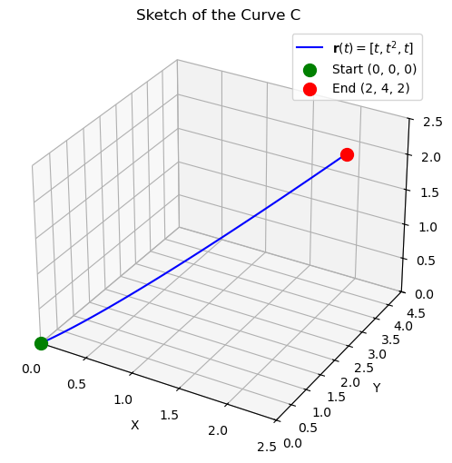

```python
# Import required libraries
import numpy as np
import matplotlib.pyplot as plt
from mpl_toolkits.mplot3d import Axes3D

# Define the parameter t
t = np.linspace(0, 2, 100)  # 100 points from t=0 to t=2

# Parametric equations
x = t
y = t**2
z = t

# Create a 3D plot
fig = plt.figure(figsize=(8, 6))
ax = fig.add_subplot(111, projection='3d')

# Plot the curve
ax.plot(x, y, z, label=r'$\mathbf{r}(t) = [t, t^2, t]$', color='blue')

# Mark the start and end points
ax.scatter([0], [0], [0], color='green', s=100, label='Start (0, 0, 0)')
ax.scatter([2], [4], [2], color='red', s=100, label='End (2, 4, 2)')

# Set labels and title
ax.set_xlabel('X')
ax.set_ylabel('Y')
ax.set_zlabel('Z')
ax.set_title('Sketch of the Curve C')
ax.legend()

# Set axis limits for better visualization
ax.set_xlim(0, 2.5)
ax.set_ylim(0, 4.5)
ax.set_zlim(0, 2.5)

# Show the plot
plt.show()
```